# A comprehensive DNA barcode database for Central European beetles with a focus on Germany: adding more than 3500 identified species to BOLD - Hendrich - 2015 - Molecular Ecology Resources - Wiley Onli

[Molecular Ecology Resources](https://onlinelibrary.wiley.com/journal/17550998)

[Volume 15, Issue 4](https://onlinelibrary.wiley.com/toc/17550998/2015/15/4) p. 795-818

[figure not shown]

Resource Article

Open Access

# A comprehensive DNA barcode database for Central European beetles with a focus on Germany: adding more than 3500 identified species to BOLD

[Lars Hendrich](https://onlinelibrary.wiley.com/authored-by/ContribAuthorRaw/Hendrich/Lars),

Joint first authors.

[Jérôme Morinière](https://onlinelibrary.wiley.com/authored-by/ContribAuthorRaw/Morini%C3%A8re/J%C3%A9r%C3%B4me),

Joint first authors.

[Gerhard Haszprunar](https://onlinelibrary.wiley.com/authored-by/ContribAuthorRaw/Haszprunar/Gerhard),

[Paul D. N. Hebert](https://onlinelibrary.wiley.com/authored-by/ContribAuthorRaw/Hebert/Paul+D.+N.),

[Axel Hausmann](https://onlinelibrary.wiley.com/authored-by/ContribAuthorRaw/Hausmann/Axel),

[Frank Köhler](https://onlinelibrary.wiley.com/authored-by/ContribAuthorRaw/K%C3%B6hler/Frank),

[Michael Balke](https://onlinelibrary.wiley.com/authored-by/ContribAuthorRaw/Balke/Michael),

First published: 03 December 2014

https://doi.org/10.1111/1755-0998.12354

Citations: 146

## Abstract

Beetles are the most diverse group of animals and are crucial for ecosystem functioning. In many countries, they are well established for environmental impact assessment, but even in the well-studied Central European fauna, species identification can be very difficult. A comprehensive and taxonomically well-curated DNA barcode library could remedy this deficit and could also link hundreds of years of traditional knowledge with next generation sequencing technology. However, such a beetle library is missing to date. This study provides the globally largest DNA barcode reference library for Coleoptera for 15 948 individuals belonging to 3514 well-identified species (53% of the German fauna) with representatives from 97 of 103 families (94%). This study is the first comprehensive regional test of the efficiency of DNA barcoding for beetles with a focus on Germany. Sequences ≥500 bp were recovered from 63% of the specimens analysed (15 948 of 25 294) with short sequences from another 997 specimens. Whereas most specimens (92.2%) could be unambiguously assigned to a single known species by sequence diversity at CO1, 1089 specimens (6.8%) were assigned to more than one Barcode Index Number (BIN), creating 395 BINs which need further study to ascertain if they represent cryptic species, mitochondrial introgression, or simply regional variation in widespread species. We found 409 specimens (2.6%) that shared a BIN assignment with another species, most involving a pair of closely allied species as 43 BINs were involved. Most of these taxa were separated by barcodes although sequence divergences were low. Only 155 specimens (0.97%) show identical or overlapping clusters.

## Introduction

Beetles are the most diverse order of insects with nearly 400 000 described species (Zhang 2011). The fauna of Germany includes 6631 species in 103 families while 8985 species occur in Central Europe (Köhler & Klausnitzer 1998). These species possess enormous morphological and ecological diversity and provide numerous ecosystem services – with many species wood boring, herbivorous or carnivorous and adapted to both terrestrial and aquatic habitats (Köhler & Klausnitzer 1998), whereas many larvae are inhabitants of subterranean habitats. The beetle fauna of Europe is well known as there is a very active community of professional and amateur entomologists studying their taxonomy and ecology. This is especially true for the Central European fauna which has a taxonomic history that predates Linnaeus. Because their extreme species richness is coupled with morphological, ecological and behavioural diversity, beetles are widely used for environmental impact assessments (EIAs), ecological studies and monitoring activities (Foster *et al*. 1989; Lindhe *et al*. 2005; Jurc 2012; Bicknell *et al*. 2014). While their value for EIAs is undisputed, there remains a need to better understand habitat requirements, especially of their larvae, as well as interactions between species (Rainio & Niemelä 2003). This often requires improved taxonomic tools.

Certain beetle species are serious pests in agriculture and forestry, with some causing economic losses of billions of euros (Germain *et al*. 2013; Jordal & Kambestad 2014). Invasive species, such as the Asian ladybird, *Harmonia axyridis* Pallas, 1773, are now a threat to the native European Coccinellidae fauna (Fischer 2013; Lombaert *et al*. 2014). On the other hand, the ladybird *Coccinella septempunctata* Linnaeus, 1758 is useful for pest control (Bianchi *et al*. 2013) and the defence secretions of *Harmonia axyridis* have medical applications (Röhrich *et al*. 2012).

DNA barcoding provides an efficient method for biodiversity assessment as it meets the need for fast, efficient and reliable species identification at this time of climate change and massive habitat destruction (Hebert & Gregory 2005; Valentini *et al*. 2009). This approach is arguably the best way to handle the vast diversity of invertebrates which are crucial for ecosystem functioning but often poorly known taxonomically. DNA barcoding also has the power to connect different life stages such as eggs, larvae and adults. As such, it can link hundreds of years of taxonomic, ecological, faunistic and ethological studies with ultra-high-throughput sequencing the genomic era. The latter approach will have great benefits for many application-oriented fields, especially in agriculture and forestry where the rapid and reliable identification of bulk samples is critical.

Strongly validated, reliable species libraries are of importance as climatic change and global distribution of goods facilitate the movement of invasive species, which, after being introduced, might exhibit greater ecological damage outside their native habitat. However, identification success is only as good as the underlying database (Kvist 2013). To date, most published DNA barcoding studies dealing with insects have focused on Hymenoptera and Lepidoptera, while few recent studies have examined the hyperdiverse Coleoptera (Woodcock *et al*. 2013; Pentinsaari *et al*. 2014). Bergsten *et al*. found that a minimum of 70 specimens needed to be analysed to sample 95% of its intraspecific variation in the species they examined (Bergsten *et al*. 2012a). However, the local DNA barcode library developed in this study provides an important foundation for future efforts to better assess intraspecific variation projects. This publication begins to address this deficit by releasing the largest Coleoptera barcode reference library to date, focused on the heart of Europe. The records provide coverage for 15 948 beetle specimens (3514 species), 53% of the German and 39% of the Central European fauna (Köhler & Klausnitzer 1998). This release is a direct result of the Barcoding Fauna Bavarica project (http://www.faunabavarica.de) led by the Bavarian State Collection of Zoology (SNSB-ZSM) with support from the Bavarian State Government (Haszprunar 2009). With an area of 70 000 km<sup>2</sup>, Bavaria is the largest German state and possesses all major habitat types in Germany (except coastal regions) and harbours 90% of the terrestrial and freshwater species known from Germany. Due to its diverse habitats, Bavaria also hosts approximately 70% of the Central European fauna. In 2012, DNA barcoding was elevated to a national mission through the establishment of the ‘German Barcode of Life (GBOL)’ project (http://www.bolgermany.de), led by the Zoologisches Forschungsmuseum Alexander Koenig in Bonn (ZFMK), but involving strong participation by other German institutions including the SNSB-ZSM. In close cooperation with the Biodiversity Institute of Ontario (BIO, Guelph, Canada), the German barcoding projects aim to assemble a DNA barcode library for all animal species present in Germany in the framework of the International Barcode of Life (iBOL) Project.

## Materials and methods

### Fieldwork

A network of taxonomists and citizen scientists collected specimens from Bavaria and from other German states to obtain species which are rare in Bavaria. Field work permits were issued by the responsible state environmental offices of Bavaria [Bayerisches Staatsministerium für Umwelt und Gesundheit, Munich, Germany, project: ‘Barcoding Fauna Bavarica’]. The study sites included more than 537 localities in state forests, public lands and protected areas such as the National Parks ‘Bayerischer Wald’ and ‘Berchtesgadener Land’. The general distribution of all included species, based on literature cited below, can be studied in Fig. S3 and Table S3 (Supporting information).

### Specimens and taxonomy

Vouchers from Germany (13 470), Austria (689), Belgium (515), Northern Italy (436), France (392) and other countries (448) are now stored in SNSB-ZSM with the exception of a few specimens in private collections. In 5 years, 538 800 specimens of beetles were collected using various methods (i.e. hand collecting, sweep-netting, Malaise-, window- and pitfall-traps) which were deployed in varied aquatic and terrestrial habitats (Koch 1989, 1991, 1992, 1993, 1994, 1995a,b, 1996; Köhler, F unpublished, see Figs S1 and S2, Tables S1 and S2, Supporting information). From this total, 462 550 specimens were sorted and identified to a species level and more than 25 000 specimens were submitted for sequence analysis, according to an internal catalogue of missing species (Köhler, F unpublished). Only a few specimens were pinned, and few were more than 5 years old. The number of specimens analysed per species ranged from 1–26 in *Adalia bipunctata* (Linnaeus, 1758) (see Appendices S1 and S2, Supporting information), available on Dryad doi:10.5061/dryad.gg8fg. Individuals were identified to species level either by Frank Köhler and/or by other taxonomic specialists, using appropriate literature (e.g. Freude *et al*. 1964-1983; Lohse & Lucht 1989, 1992; Drost *et al*. 1992; Pfeffer 1994; Hebauer & Klausnitzer 1998; Lompe 2014: http://www.coleo-net.de/coleo/index.htm).

### Laboratory protocols

A tissue sample was removed from each specimen and transferred into 96-well plates at the SNSB-ZSM for subsequent DNA extraction. For specimens with a body length >2 mm, a single leg or a leg segment was removed for DNA extraction. The whole voucher was used for some very small specimens (e.g. ≤1 mm, Ptiliidae), but replacement vouchers from the same locality were retained. In other cases (vouchers from Malaise traps), DNA was extracted from the whole voucher at the CCDB (Guelph, Canada) using voucher-recovery protocols and the specimens were repatriated to the SNSB-ZSM for identification and curation. Voucher information such as locality data, habitat, altitude, collector, identifier, taxonomic classifications, habitus images, DNA barcode sequences, primer pairs and trace files are publicly accessible in the ‘German Beetles’ data set in BOLD (http://www.boldsystems.org – data set DOI: dx.doi.org/10.5883/DS-COLBYGER).

Once tissue samples were added, the plates were sent to the Canadian Centre for DNA Barcoding (CCDB) where they were processed using standard barcoding protocols. All protocols for DNA extraction, PCR amplifications and Sanger sequencing procedures are available online under: http://www.dnabarcoding.ca/pa/ge/research/protocols.

All samples were PCR amplified with modified Folmer primers CLepFolF (5′ – ATT CAA CCA ATC ATA AAG ATA TTG G) and CLepFolR (5′ – TAA ACT TCT GGA TGT CCA AAA AAT CA) for the barcoding fragment (5′ CO1), and the same primers were employed for subsequent Sanger sequencing reactions (see also Ivanova *et al*. 2007; Ward *et al*. 2008). The sequence data and trace files were uploaded to BOLD and subsequently also to GenBank (accession nos KM439102–KM452702).

### Data analysis

Sequence divergences for the barcode region (mean and maximum intraspecific variation and minimum genetic distance to the nearest neighbour species) were calculated using the ‘Barcode Gap Analysis’ tool on BOLD, employing the Kimura-2-Parameter (K2P) distance metric (Puillandre *et al*. 2012). MUSCLE was applied for sequence alignment restricting analysis to sequences with a minimum length of 500 bp. Neighbour-joining (NJ) trees for each family were calculated following alignment based on K2P distances. The ‘BIN Discordance’ analysis on BOLD was used to reveal species clusters which shared a BIN, and those which were assigned to two or more BINs. BOLD groups sequences into clusters of closely similar CO1 barcode sequences which are assigned a globally unique identifier, termed a ‘Barcode Index Number’ or BIN (Ratnasingham & Hebert 2013). This system can be used to verify the species identifications when taxonomic information is lacking. The BIN System involves a 3-step online pipeline, which clusters similar barcode sequences algorithmically into operational taxonomic units (OTUs). Members of a BIN often belong to a single species as delineated by traditional taxonomy (Hausmann *et al*. 2013). Every ‘disagreement/conflict’ case is the starting point for re-evaluation of both molecular and morphological data. We follow the concept of integrative taxonomy (Padial *et al*. 2010; Schlick-Steiner *et al*. 2010, 2014; Fujita *et al*. 2012; Riedel *et al*. 2013) to infer whether there are previously overlooked species in the sample, or if barcode divergence between species is too low or absent to allow the species to be delineated using only CO1.

## Results

Table 1. The rate of success in recovery of barcode sequences for species belonging to 97 of 103 families of Coleoptera recorded from Germany and Central Europe

[output not shown]

[output cut: 68 more lines]

Subsequent analyses were restricted to sequence records ≥500 bp (Fig. 1A and B). These 15 948 sequences provided coverage for 3514 German species (53%) that were assigned to 3687 BINs (Fig. 2). In total, 524 new BINs were added to BOLD, most representing new species entries for the BOLD system. Inspection of the sequence clusters in the neighbour-joining (NJ) tree revealed high congruence with morphology-based identifications. In fact, 92.2% of the species could be unambiguously identified by their CO1 sequence. However, in a total of 176 cases, 1089 specimens (6.8%) were represented by more than one BIN, producing a total of 395 BINs for these taxa. Another 42 species pairs and one species trio shared BINS meaning that 409 specimens (2.6%) were involved in BIN sharing. Many of these species pairs (28) could be separated by CO1 because their members were assigned to different subclusters, but 155 specimens (0.97%) including 15 pairs and one trio possessed identical or overlapping CO1 barcode sequences that prevented their discrimination.

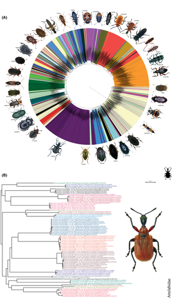

**Figure 1**

Open in figure viewer[PowerPoint](https://onlinelibrary.wiley.com/action/downloadFigures?id=men12354-fig-0001&doi=10.1111%2F1755-0998.12354)

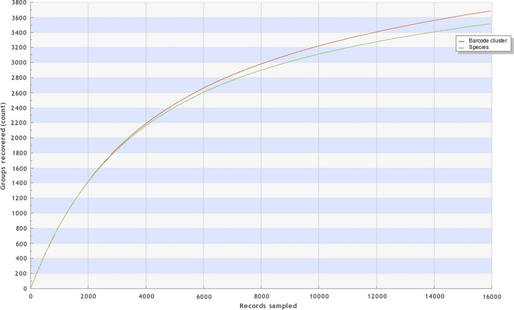

**Figure 2**

Open in figure viewer[PowerPoint](https://onlinelibrary.wiley.com/action/downloadFigures?id=men12354-fig-0002&doi=10.1111%2F1755-0998.12354)

Accumulation curve for the 3514 species and 3687 BINs with DNA barcodes from Central European species. The accumulation curve (from BOLD database; randomized; 100 iterations) is based on data for the 15 948 barcoded individuals (>500 bp).

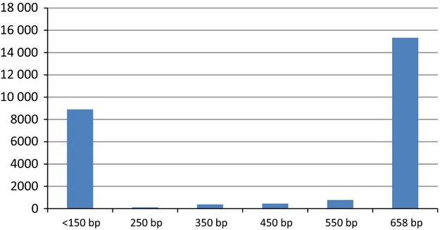

**Figure 3**

Open in figure viewer[PowerPoint](https://onlinelibrary.wiley.com/action/downloadFigures?id=men12354-fig-0003&doi=10.1111%2F1755-0998.12354)

Success rate in N specimens in recovering CO1 amplicons of varied length.

Appendix S3 (Supporting information) provides neighbour-joining trees for all families with more than one species. Besides the species name, a voucher number, region and country of origin are given for each specimen (available under doi: 10.5061/dryad.gg8fg).

### BIN sharing and paraphyletic species

Table 2. Cases of BIN sharing involving 42 pairs and one triplet of congeneric species of German Coleoptera (409 specimens). The minimum pairwise distance (PD) for each pair or triad is shown as well as their BIN

| Family | Species 1 | Species 2 | Species 3 | Min PD % | Shared BIN |
| --- | --- | --- | --- | --- | --- |
| Carabidae | *Bembidion atrocaeruleum* | *Bembidion varicolor* |  | 0 | BOLD:AAO0687 |
| Carabidae | *Bembidion guttula* | *Bembidion mannerheimii* |  | 0 | BOLD:AAW3426 |
| Cerambycidae | *Anastrangalia dubia* | *Anastrangalia reyi* |  | 0 | BOLD:AAJ2081 |
| Mordellidae | *Mordella brachyura* | *Mordella holomelaena* |  | 0 | BOLD:ACG2749 |
| Mycetophagidae | *Mycetophagus piceus* | *Mycetophagus salicis* |  | 0 | BOLD:AAK8784 |
| Oedemeridae | *Anogcodes dispar* | *Anogcodes fulvicollis* |  | 0 | BOLD:ACI6135 |
| Phalacridae | *Olibrus affinis* | *Olibrus flavicornis* |  | 0 | BOLD:AAQ0763 |
| Staphylinidae | *Aleochara bipustulata* | *Aleochara verna* |  | 0 | BOLD:AAJ2457 |
| Staphylinidae | *Atheta malleus* | *Atheta volans* |  | 0 | BOLD:AAN2267 |
| Staphylinidae | *Bledius filipes* | *Bledius terebrans* |  | 0 | BOLD:AAO4729 |
| Staphylinidae | *Euplectus kirbyi* | *Euplectus nanus* |  | 0 | BOLD:AAO0162 |
| Staphylinidae | *Haploglossa nidicola* | *Haploglossa villosula* |  | 0 | BOLD:AAK5150 |
| Staphylinidae | *Leptacinus formicetorum* | *Leptacinus intermedius* | *Leptanicus sulcifrons* | 0 | BOLD:AAO1025 |
| Staphylinidae | *Myllaena infuscata* | *Myllaena minuta* |  | 0 | BOLD:AAX2901 |
| Staphylinidae | *Tachyporus chrysomelinus* | *Tachyporus dispar* |  | 0 | BOLD:AAN9511 |
| Carabidae | *Dyschirius agnathus* | *Dyschirius politus* |  | 0.15 | BOLD:AAO3582 |
| Curculionidae | *Anthonomus humeralis* | *Anthonomus pomorum* |  | 0.15 | BOLD:AAO1532 |
| Staphylinidae | *Gyrophaena polita* | *Gyrophaena strictula* |  | 0.15 | BOLD:AAO0297 |
| Carabidae | *Agonum micans* | *Agonum striatum* |  | 0.16 | BOLD:AAN9978 |
| Chrysomelidae | *Phratora polaris* | *Phratora tibialis* |  | 0.3 | BOLD:ABA3280 |
| Curculionidae | *Miarus campanulae* | *Miarus ajugae* |  | 0.3 | BOLD:ABW4930 |
| Carabidae | *Harpalus anxius* | *Harpalus subcylindricus* |  | 0.31 | BOLD:ABZ8076 |
| Carabidae | *Dyschirius arenosus* | *Dyschirius obscurus* |  | 0.46 | BOLD:AAP8268 |
| Curculionidae | *Miarus abnormis* | *Miarus ajugae* |  | 0.46 | BOLD:ABW4930 |
| Dytiscidae | *Bidessus delicatulus* | *Bidessus minutissimus* |  | 0.46 | BOLD:AAB7463 |
| Staphylinidae | *Lithocharis nigriceps* | *Lithocharis ochraceus* |  | 0.49 | BOLD:AAN6200 |
| Carabidae | *Harpalus servus* | *Harpalus subcylindricus* |  | 0.61 | BOLD:ABZ8076 |
| Carabidae | *Pterostichus cristatus* | *Pterostichus hagenbachii* |  | 0.61 | BOLD:ACG2758 |
| Curculionidae | *Microplontus campestris* | *Microplontus millefolii* |  | 0.66 | BOLD:AAO1007 |
| Carabidae | *Agonum afrum* | *Agonum duftschmidi* |  | 0.77 | BOLD:AAO3378 |
| Cerylonidae | *Cerylon ferrugineum* | *Cerylon histeroides* |  | 0.83 | BOLD:AAN9867 |
| Carabidae | *Amara ovata* | *Amara similata* |  | 0.92 | BOLD:AAJ5377 |
| Staphylinidae | *Amischa analis* | *Amischa bifoveolata* |  | 0.92 | BOLD:ABA5313 |
| Carabidae | *Harpalus attenuatus* | *Harpalus rubripes* |  | 1.07 | BOLD:AAI2024 |
| Staphylinidae | *Lathrobium quadratum* | *Lathrobium terminatum* |  | 1.07 | BOLD:AAX0188 |
| Carabidae | *Carabus alpestris* | *Carabus sylvestris* |  | 1.08 | BOLD:ABU7358 |
| Dytiscidae | *Rhantus bistriatus* | *Rhantus suturellus* |  | 1.13 | BOLD:AAQ1027 |
| Chrysomelidae | *Galerucella aquatica* | *Galerucella nymphaeae* |  | 1.23 | BOLD:AAG4421 |
| Carabidae | *Dyschirius thoracicus* | *Dyschirius arenosus* |  | 1.29 | BOLD:AAP8268 |
| Staphylinidae | *Heterothops niger* | *Heterothops stiglundbergi* |  | 1.7 | BOLD:AAX0829 |
| Carabidae | *Limodromus assimilis* | *Limodromus longiventris* |  | 1.85 | BOLD:AAN9741 |
| Attelabidae | *Rhynchites auratus* | *Rhynchites bacchus* |  | 1.86 | BOLD:ACG5878 |
| Carabidae | *Panagaeus cruxmajor* | *Panagaeus bipustulatus* |  | 2.03 | BOLD:AAO4843 |

*Anastrangalia dubia* (Scopoli, 1763) and *A. reyi* (Heyden, 1889) are longhorn beetles (Cerambycidae) that occur throughout Europe with the latter taxon also found in Turkey, Iran, Central Asia, China and Mongolia. The two sexes as well as local populations of the species may have different colours (black, brown and red). The two species are morphologically very similar, but can be separated by the form of the head which has angular margins beneath the eyes in *A. dubia*, but round ones in *A. reyi* (Bense 1995). Sequences do not recover either species as a monophyletic cluster (Fig. 4A).

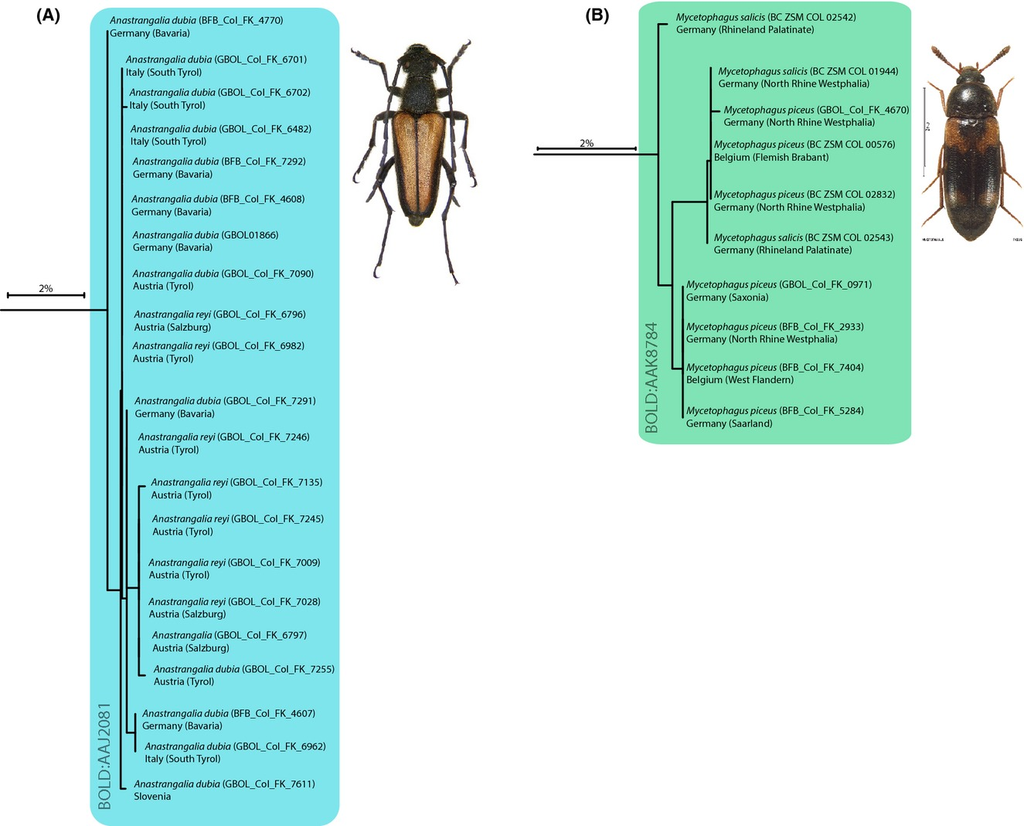

**Figure 4**

Open in figure viewer[PowerPoint](https://onlinelibrary.wiley.com/action/downloadFigures?id=men12354-fig-0004&doi=10.1111%2F1755-0998.12354)

NJ subtrees for species pairs that share a barcode sequence. NJ trees were obtained from BOLD.

*Mycetophagus piceus* (Fabricius, 1777) and *M. salicis* Brisout de Barneville, 1862 are widespread European hairy fungus beetles (Mycetophagidae) which can be separated by the colour of the dorsal surface of their pronotum and elytra and the form of the male genitalia, median lobe and parameres (Lompe 2014). The species are found in different habitats as *M. salicis* lives in bracket fungus on softwood trees such as willow while *M. piceus* feeds on bracket fungus overgrown by mycelium on hardwood trees such as oak. Sequences within the BIN do not recover either species as a monophyletic clade, highlighting the need for an in-depth analysis of the status of these two species (Fig. 4B).

### BIN sharing with monophyletic species

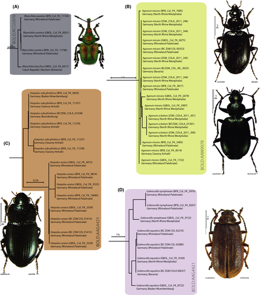

**Figure 5**

Open in figure viewer[PowerPoint](https://onlinelibrary.wiley.com/action/downloadFigures?id=men12354-fig-0005&doi=10.1111%2F1755-0998.12354)

NJ subtrees for species pairs with low interspecific variation. NJ trees were obtained from BOLD.

The peach weevil *Rhynchites bacchus* (Linnaeus, 1758) and the cherry weevil *R. auratus* (Scopoli, 1763) (Attelabidae) are serious pests in fruit orchards (Hassler & Rheinheimer 2010). *R. bacchus* has a black snout while *R. auratus* has a metallic snout. The punctation on the pronotum of *R. bacchus* is coarser than in *R. auratus*, while the eyes in *R. bacchus* are strongly prominent, butmore inserted in *R. auratus*. Although they are morphologically and ecologically distinct species, they share a BIN but show a minimum K2P distance of 1.86% (Fig. 5A).

*Agonum scitulum* Dejean, 1828 and *A. micans* (Nicolai, 1822) are two morphologically very similar ground beetles (Carabidae) which can be only separated by the form of male genitalia (Schmidt 2006). *A. micans* is a Eurosiberian boreotemperate species, strongly associated with wet alder forests on water-logged river and lakeshore soils. It occurs across Europe except in the south, and east into western Siberia. *A. scitulum* is hygrophilic ground beetle, favoring wet woodlands and well-vegetated marshes, particularly adjacent to tidal rivers. It occurs throughout Europe from western France and Great Britain, to Russia and Romania in the east, southwards to Switzerland. The three specimens of *A. scitulum* examined in this study shared a distinctive haplotype, but the 14 individuals of *A. micans* form a paraphyletic assemblage (Fig. 5B).

*Harpalus anxius* (Duftschmidt, 1812) and *H. subcylindricus* Dejean, 1829 are ground beetles (Carabidae) which share a BIN but each species forms a distinct cluster (Fig. 5C). *H. subcylindricus* is restricted to dry, warm, sparsely vegetated habitats such as arid and semi-arid grasslands although it occasionally co-occurs with *H. anxius*. However, *H. anxius* is only found on sandy soils, while *H. subcylindricus* occurs elsewhere. Males can be distinguished by the differing shape of their median lobes, but females cannot be discriminated morphologically (Butterweck *et al*. 2000).

The sibling species *Galerucella aquatica* (Geoffroy in Fourcroy, 1785) and *G. nymphaeae* (Linnaeus, 1758) (Chrysomelidae) employ differing host plants. *G. nymphaeae* feeds on *Nuphar* and *Nymphaea* (water lilies) while *G. aquatica* consumes Polygonaceae (Lopatin & Nesterova 2005). While males can be identified by the different structure of their genitalia, females cannot be discriminated without knowledge of the host plant (Fig. 5D). However, they can now be recognized using DNA barcoding (minimum K2P distance = 1.23%).

### High genetic divergences within species and cases of cryptic diversity

Table 3. 176 cases in which high intraspecific divergence (ISD) led to the assignment of conspecific individuals to two or more BINs (1089 specimens)

| Family | Species | Country | BIN | Max ISD |  |  |  |  |  |  |  |  |
| --- | --- | --- | --- | --- | --- | --- | --- | --- | --- | --- | --- | --- |
| Anthicidae | *Cyclodinus humilis* | DE | BOLD:ACD0890 | 2.65 |  |  |  |  |  |  |  |  |
|  |  | DE | BOLD:ACG8457 |  |  |  |  |  |  |  |  |  |
| Anthribidae | *Araecerus fasciculatus* | NL | BOLD:AAH0210 |  | 3.75 |  |  |  |  |  |  |  |
|  |  | NL | BOLD:ACC2424 |  |  |  |  |  |  |  |  |  |
| Attelabidae | *Attelabus nitens* | DE | BOLD:AAO4568 | 4.68 |  |  |  |  |  |  |  |  |
|  |  | DE | BOLD:ACG7055 |  |  |  |  |  |  |  |  |  |
| Bothrideridae | *Teredus cylindricus* | DE | BOLD:AAO4189 |  |  | 2.47 |  |  |  |  |  |  |
|  |  | DE | BOLD:AAO0452 |  |  |  |  |  |  |  |  |  |
| Brentidae | *Eutrichapion punctigerum* | DE | BOLD:ABX3008 | 1.48 |  |  |  |  |  |  |  |  |
|  |  | DE | BOLD:ACE5095 |  |  |  |  |  |  |  |  |  |
|  | *Protapion fulvipes* | DE | BOLD:ACF5056 |  | 1.85 |  |  |  |  |  |  |  |
|  |  | DE | BOLD:AAX8468 |  |  |  |  |  |  |  |  |  |
|  | *Pseudapion moschatae* | DE | BOLD:ACD0419 | 3.28 |  |  |  |  |  |  |  |  |
|  |  | DE | BOLD:AAO1152 |  |  |  |  |  |  |  |  |  |
|  | *Stenopterapion tenue* | DE | BOLD:ACG4488 |  |  |  | 6.8 |  |  |  |  |  |
|  |  | DE | BOLD:AAO3660 |  |  |  |  |  |  |  |  |  |
|  |  | DE | BOLD:ACA7465 |  |  |  |  |  |  |  |  |  |
|  |  | DE | BOLD:ACG9508 |  |  |  |  |  |  |  |  |  |
| Buprestidae | *Agrilus viridis* | DE | BOLD:ACE6725 | 1.85 |  |  |  |  |  |  |  |  |
|  |  | DE | BOLD:ACE5550 |  |  |  |  |  |  |  |  |  |
| Byrrhidae | *Cytilus sericeus* | BE/DE | BOLD:ACG4339 |  | 4.09 |  |  |  |  |  |  |  |
|  |  | DE | BOLD:ACG3560 |  |  |  |  |  |  |  |  |  |
|  |  | AU/IT | BOLD:AAJ5113 |  |  |  |  |  |  |  |  |  |
|  |  | DE | BOLD:ACG3559 |  |  |  |  |  |  |  |  |  |
| Cantharidae | *Cantharis sudetica* | FR | BOLD:ACB8167 | 3.13 |  |  |  |  |  |  |  |  |
|  |  | FR | BOLD:ACB9515 |  |  |  |  |  |  |  |  |  |
|  | *Cantharis tristis* | IT | BOLD:ABU8563 |  |  | 3.25 |  |  |  |  |  |  |
|  |  | DE/FR | BOLD:AAW8261 |  |  |  |  |  |  |  |  |  |
|  | *Malthodes mysticus* | DE | BOLD:ACC5434 | 3.46 |  |  |  |  |  |  |  |  |
|  |  | DE | BOLD:ABU9145 |  |  |  |  |  |  |  |  |  |

[output cut: 367 more lines]

#### Species with high intraspecific variation without correlated differences in morphology

Four species of Haliplidae (*Haliplus furcatus* Seidlitz, 1887, *H. immaculatus* Gerhardt, 1877, *H. ruficollis* (De Geer, 1774) and *H. variegatus* Sturm, 1834) show high intraspecific divergences from 1.23% in *H. variegatus* to 2.66% in *H. immaculatus* (Table 3) (Fig. 6A). However, in contrast to *H. lineatocollis* (Marsham, 1802) (see below), morphological analysis of the voucher specimens (performed by the first author) did not reveal evidence of morphological divergence between the specimens in each cluster.

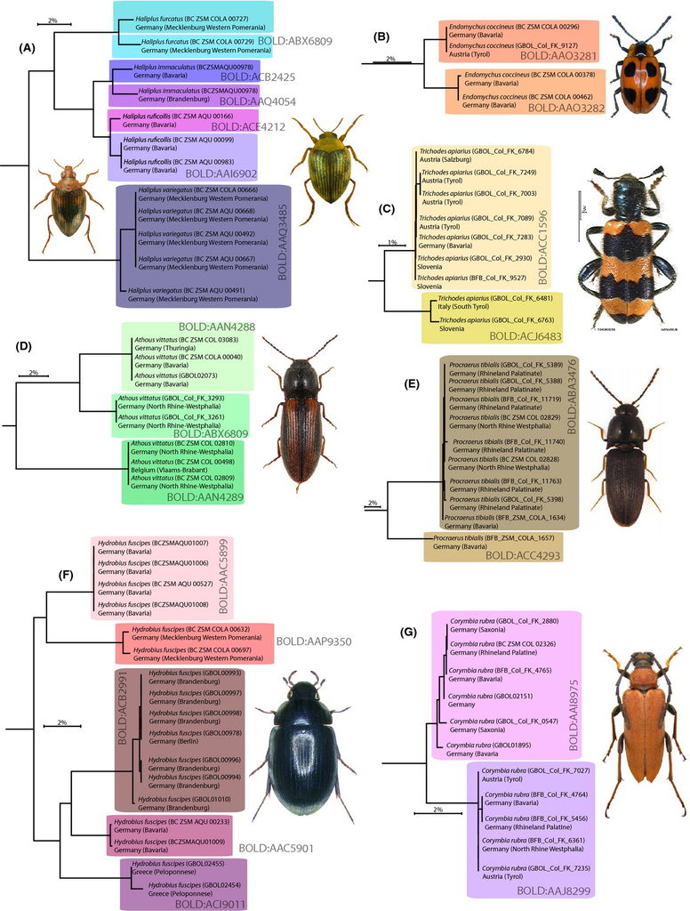

**Figure 6**

Open in figure viewer[PowerPoint](https://onlinelibrary.wiley.com/action/downloadFigures?id=men12354-fig-0006&doi=10.1111%2F1755-0998.12354)

NJ subtrees for species pairs with high intraspecific variation that may represent cases of cryptic diversity. NJ trees were obtained from BOLD.

The false ladybird *Endomychus coccineus* (Linnaeus, 1758) (Endomychidae) belongs to a monotypic genus that is widespread in Central European forests. The larvae are often prevalent on fungi growing on birch and beech stumps. The maximum intraspecific divergence (ISD) between the two BINs is 3.12% (Table 3) (Fig. 6B).

*Trichodes apiarius* Herbst, 1792 a checkered beetle, is the most common species of the genus in Central Europe. Its larval stage parasitizes bees, predating on the larvae and nymphs of both solitary bees (e.g. *Osmia* and *Megachile*) and honey bees. The adults feed on the pollen of flowers, mainly Apiaceae, in May through June (Niehuis 2013). The maximum intraspecific divergence (ISD) between the two BINs is 3.44% (Table 3) (Fig. 6C).

#### Possible cases of cryptic diversity

The following paragraph provides details for nine possible cases of cryptic diversity involving species clusters, most with more than 5% divergence. For *Corymbia rubra* (Linnaeus, 1758) and *Leptinus testaceus* Müller, 1817 minimum pairwise distances are 3.45% and 2.49%, respectively (Table 3), but no closely related sister species are known from Central Europe.

*Athous vittatus* Fabricius, 1793 is a common click beetle (Elateridae) with variable dorsal coloration (Laibner 2000). Several colour forms have been described and named. The fact that specimens of this species were divided into three clusters with a maximum divergence of 15.75% suggests that this taxon is actually composed of two if not three species in Germany (Fig. 6D).

*Procraerus tibialis* (Lacordaire, 1835), another elaterid, belongs to a monotypic genus in Europe and occurs in the cavities of deciduous trees infested by *Rhamnusium bicolor* (Schrank, 1781) (Cerambycidae) and cossonine weevils (Husler & Husler 1940). The adults are only active at night, remaining hidden in crevices or under bark during the day. Adults can be reared from dry wood of old oaks (Németh & Merkl 2009). A single specimen from southern Bavaria possessed a Max ISD of 13.64% from a cluster of nine specimens (Table 3) collected in different regions of Germany including northern Bavaria (Fig. 6E). As one junior synonym (*Ampedus subcarintus* Germar, 1844) exists for this species, further specimens from Europe should be barcoded including the type specimens of both taxa to clarify the taxonomic status of the barcode lineages.

*Hydrobius fuscipes* (Linnaeus, 1758) is one of the most widespread water scavenger beetles (Hydrophilidae) in lentic habitats across the entire Holarctic region including North America, China and Mongolia (Hansen 1987). Three morphological variants of this species from Germany were named in the past, but were later synonymized and have not been ranked as species or subspecies in recent faunal treatments (Drost *et al*. 1992; Hebauer & Klausnitzer 1998). Taking into account the geographical scale and number of specimens studied (*n* = 15), the barcode results suggest that at least four (probably) allopatric species occur in Germany (Table 3), with an additional taxon in Greece (Fig. 6F). The occurrence of these lineages needs to be investigated across the whole distribution of this probable species complex. Morphometric data and additional molecular markers were recently assembled for a comprehensive study examining the boundaries of this species complex in Fennoscandia. Their study includes examination of available type material and support the presence of four species in addition to the barcode clusters found in our study, including *H. arcticus* and the formally established morphological variants of *H. fuscipes* (Fossen 2014; E. I. Fossen, T. Ekrem, J. Bergsten & A. Nilsson, unpublished).

*Corymbia rubra* (Linnaeus, 1758), the red-brown longhorn beetle (Cerambycidae), is a well-known xylophagous inhabitant of coniferous forests throughout Central Europe whose larvae feed in the dead wood of spruce and pine trees. The distinctive colour of this species has traditionally allowed a straightforward identification (Bense 1995). As a result, it is remarkable that this taxon likely includes two species as evidenced by the presence of 3.45% divergence (Table 3) between members of the two clusters (Fig. 6G). However, there remains a need for more comprehensive, integrative investigations to validate this conclusion.

The well-known thistle tortoise beetle (Chrysomelidae) *Cassida rubiginosa* Müller, 1776 feeds on Canada thistle (*Cirsium arvense*) and was intentionally introduced to the United States and New Zealand to control thistles (Asadi *et al*. 2013). Given its importance as a biological control agent, it is interesting that it is represented by at least three distinct clades in Germany (Fig. 7A).

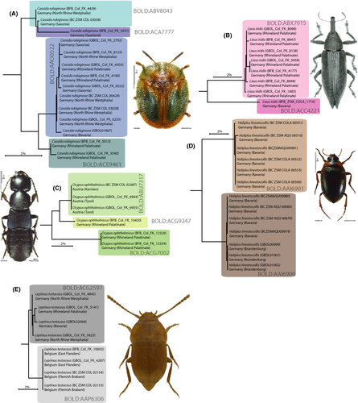

**Figure 7**

Open in figure viewer[PowerPoint](https://onlinelibrary.wiley.com/action/downloadFigures?id=men12354-fig-0007&doi=10.1111%2F1755-0998.12354)

NJ subtrees for species pairs with high intraspecific variation that may represent cases of cryptic diversity. NJ trees were obtained from BOLD.

*Lixus iridis* (Olivier, 1807)*,* one of the largest (body length = 17 mm) weevils (Curculionidae) in Germany (Hassler & Rheinheimer 2010), is represented by two barcode clades. All voucher specimens have been carefully checked by specialists to exclude misidentification. The Bavarian specimen differs by 7.15% (Table 3) from a clade with seven specimens from Rhineland Palatinate (Germany) (Fig. 7B). Interestingly, the exceptional specimen shows sequence congruence with unpublished records for this species from Finland.

*Ocypus ophthalmicus* (Scopoli, 1763) is an easily identified rove beetle (Staphylinidae) because of its shiny blue coloration and large size with recent records from all states in Germany (Köhler & Klausnitzer 1998) from deciduous forests and xeric habitats, including urban areas (Kleeberg & Uhlig 2011). From most parts of Germany, only the nominotypical taxon is recorded, but nine synonyms have been designated from other regions of Europe, and six subspecies are recognized (Drugmand 1998). Although our data only include six records (Table 3), they suggest that more than one species occurs in Germany (Fig. 7C). Additional material from all parts of the country is needed to clarify the status of this species.

*Haliplus lineatocollis* (Marsham, 1802) is a common, mainly lotic and, compared to most other members of the family Haliplidae, easy to identify species which occurs in alkaline, slow-flowing streams, ditches and gravel pits. The larvae, and perhaps also the adults, feed on filamentous algae (van Vondel 1997). According to the leading taxonomic specialist for this group (Bernhard van Vondel, pers. comm.) subtle morphological differences support the presence of three species in Europe with two occurring in Germany (Fig. 7D). It will be a complex task to resolve their taxonomic status because more than 14 junior synonyms (see Nilsson & van Vondel 2005) will need to be studied, and it is desirable to extend the genetic analyses as well.

*Leptinus testaceus* is a small, pale, eyeless beetle of the family Leiodidae that lives in the nests of small mammals throughout Central Europe (Kreissl 1988). In the western Palearctic region, six species of the genus have been described (Besuchet 1980). The current barcode results suggest (Table 3) that the Central European *Leptinus* fauna is more diverse than expected although more samples need to be examined to confirm this hypothesis (Fig. 7E).

## Discussion

We encourage the coleopteran scientific community to join the DNA barcoding projects on BOLD, to aid clarification of the status of species and to assist in the description of possibly overlooked species. Discussion and commenting on specific specimens on BOLD is possible for all registered users. As the presence of nuclear mitochondrial DNA (NUMTs) is a known problem in DNA barcoding (Jordal & Kambestad 2014), we double checked the trace files for the presence of double peaks and stop codons (the latter regularly carried out by the CCDB, Guelph, in the sequence editing process). We could not find any evidence of either complexity in the observed cases. All suspicious cases of BIN sharing and cryptic diversity candidates were, moreover, compared with DNA barcode reference libraries constructed by colleagues involved in other European DNA barcoding initiatives (FINBOL, Mikko Pentinsaari; PASSIFOR, Rodolphe Rougerie). Future investigations focusing on possibly overlooked species should couple the barcode analysis of more specimens from all parts of Europe with expert morphological reappraisals and the examination of variation in nuclear genes (see Bergsten *et al*. 2012a,b) or extensive screening of the genome for nucleotide polymorphisms (i.e. SNPs).

## Acknowledgements

The project was funded by grants from the Bavarian State Ministry of Education and Culture, Science and the Arts (Barcoding Fauna Bavarica, BFB) and the German Federal Ministry of Education and Research (German Barcode of Life GBOL2: BMBF #01LI1101B). We are grateful to the research team at BIO and CCDB in Guelph (Ontario, Canada) for their great support and help and particularly to Sujeevan Ratnasingham for developing the BOLD database (BOLD; [www.boldsystems.org](http://www.boldsystems.org/)) infrastructure and the BIN management tools. The sequencing work was supported, in part, by funding from the Government of Canada to Genome Canada through the Ontario Genomics Institute, while the Ontario Ministry of Research and Innovation and NSERC supported the development of the BOLD informatics platform. We are grateful to Dr. Heinz Bussler, Boris Büche, Thomas Frase, Herbert Fuchs, Stephan Gottwald, Karsten Hannig, David Hauth, Uli Heckes, Ferdinand Heidenfelder, Monika Hess, Jürgen Hofmann, Michael Hornburg, Dieter Jungwirth, Dr. Karl-Hinrich Kielhorn, Jonas Köhler, Klaus Kuhn, Wolfgang Lorenz, Hans Mühle, Andrea Jarzabek-Müller, Dr. Jörg Müller, Dr. Reinhard Müller, Dr. Michael Raupach, Andre Skale, Franz Wachtel, Herbert Winkelmann, Erwin Weichselbaumer and Ingo Wolf (all from Germany) for providing fresh specimens of various and in many cases very rare and hard to collect species. We are very grateful to Dr. Udo Schmidt (Selbitz, Germany) (http://www.kaefer-der-welt.de/) and Bruno Dries (Bad Tölz, Germany) for permission to employ their perfect beetle photos for illustration. We also thank the student research assistants, Claire Bellanger, Amalia Braun, Mei-Yu Chen, Luciano Costa, Grit Fischer, Katharina Lindner, Patricia Guevera Noeto, Alfredo Pagnotta, Katrin Schachtl, Anouk Van't Padje and many others for picking countless legs and photographing specimens.

## References

G.H., A.H., M.B. and P.H. obtained funding. F.K., L.H., M.B. and J.M. collected the samples. L.H., J.M. and M.B. conceived and designed the experiments. J.M., L.H. and P.H. analysed the data. L.H., J.M., M.B., F.K. and P.H. wrote the manuscript. A.H. and G.H. contributed (additions/corrections) to the M.S.

## Data Accessibility

Compendium of all German beetle species used in this study including information on their geographical distribution, specimen count, BIN, mean and max ISD, nearest neighbour(NN) species and distance to NN: Appendix S1 (Supporting information) Dryad doi: 10.5061/dryad.gg8fg.

Accession nos, BOLD sample IDs and species names for all specimens used in this study: Appendix S2 (Supporting information) Dryad doi: 10.5061/dryad.gg8fg.

DNA sequences: GenBank accessions KM439102–KM452702.

Final DNA sequence assembly: Dryad doi: 10.5061/dryad.gg8fg.

Phylogenetic data (a compendium of NJ trees for species in the each of the 97 families. NJ trees were obtained from BOLD): AppendixS3 (Supporting information) Dryad doi: 10.5061/dryad.gg8fg; available on BOLD under dx.doi.org/10.5883/DS-COLBYGER BOLD project DTST.

## Citing Literature

[figure not shown]

[Volume15, Issue4](https://onlinelibrary.wiley.com/toc/17550998/2015/15/4)

July 2015

Pages 795-818

### Recommended

  [Molecular Ecology Notes](https://onlinelibrary.wiley.com/journal/14718286)

back